# Eighth Week: Text Analysis in R

### پاسخ:

4اثر موجود از ویرجینیا وولف در کتابخانه ی گوتنبرگ را بررسی می کنیم.

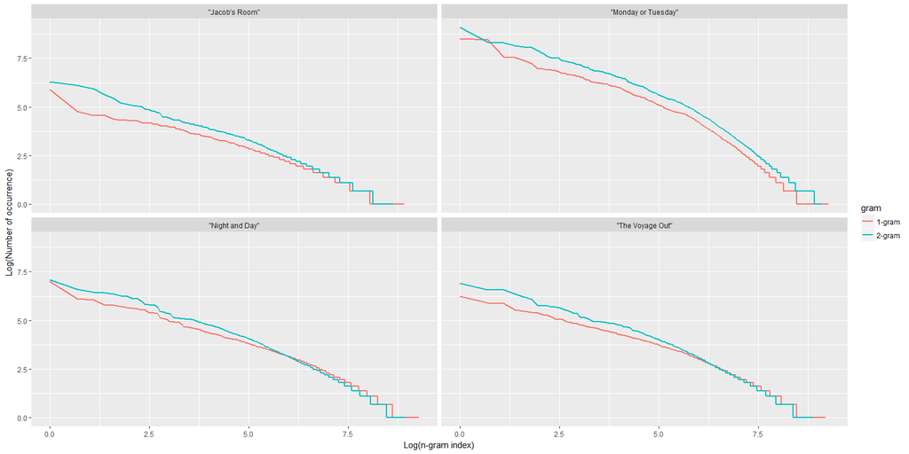

```r
gutenberg_metadata %>% filter(str_detect(author,"Woolf, Virginia")) -> Woolf

TheVoyageOut = gutenberg_download(144)
NightAndDay = gutenberg_download(1245)
JacobsRoom = gutenberg_download(5670)
MondayOrTuesday = gutenberg_download(22920)

novels = list(TheVoyageOut,NightAndDay,JacobsRoom,
              MondayOrTuesday)

ngrams = list()

for (i in 1:4){
  words = data.frame(word = novels[[i]]$text %>% str_split("\\s+") %>% unlist(),
                     stringsAsFactors = F)

  words %>%
    filter(!(str_to_lower(word) %>% str_replace_all("[:punct:]","") %in%
               (stop_words$word %>% str_replace_all("[:punct:]","")))) %>%
    filter(!(str_to_lower(word) %in% (stop_words$word %>% str_replace_all("[:punct:]","")))) -> words
  words$word =  str_replace_all(words$word,"[:punct:]","")
  words %>%   filter(!(str_to_lower(word) %in% stop_words$word)) %>%
    filter(str_length(word)>1) %>%
    filter(!str_detect(word,"\\d")) %>%
    mutate(proper = !(str_to_lower(word) %in% word )) ->words

  words$word[which(words$proper==0)] = str_to_lower(words$word[which(words$proper==0)])
  words %>% group_by(word,proper) %>%
    summarise(count = as.numeric(n())) %>%  arrange(-count) -> words
  words = data.frame(word = words$word,count = words$count,
                     rank = 1:nrow(words)) %>%
    mutate(book_no = i, gram = '1-gram')
  ngrams[[i]] = words
}


woolf_ngrams = bind_rows(ngrams)


bigrams_list = list()
for (i in 1:4){
  bigrams = novels[[i]]
  bigrams$text = str_replace_all(bigrams$text,"[:punct:]"," ")
  bigrams %>% mutate(bigram = "")->bigrams
  unnest_tokens(bigrams,bigram,text , token = "ngrams", n = 2)->bigrams

  bigrams = bigrams$bigram %>%
    as.data.frame(stringsAsFactors =F) -> bigrams

  colnames(bigrams) = c("bigram")
  bigrams %>% filter(!str_detect(bigram,"\\d")) -> bigrams
  bigrams %>%
    separate(bigram, c("word1", "word2"), sep = " ") -> bigrams_separated

  bigrams$word1 =  bigrams_separated$word1
  bigrams$word2 =  bigrams_separated$word2

  bigrams %>% filter(!(str_to_lower(word1) %in% stopwords('en')) &
                       !(str_to_lower(word1) %in% stopwords('fr')) &
                       !(str_to_lower(word2) %in% stopwords('en')) &
                       !(str_to_lower(word2) %in% stopwords('fr'))) ->bigrams

  bigrams = rbind(bigrams$word1,bigrams$word2) %>% unlist() %>%
    table() %>% as.data.frame(stringsAsFactors =F)
  colnames(bigrams) = c('word','count')
  bigrams %>% arrange(-count) -> bigrams
  bigrams$rank = 1:nrow(bigrams)
  bigrams %>% mutate(book_no = i, gram ='2-gram') -> bigrams
  bigrams_list[[i]] = bigrams
}

bigrams_list = bind_rows(bigrams_list)

woolf_ngrams = rbind(woolf_ngrams,bigrams_list)

woolf_ngrams %>% mutate(book = recode(book_no,"1='\"The Voyage Out\"';2='\"Night and Day\"';
                                3='\"Jacob\\'s Room\"';4='\"Monday or Tuesday\"'"))-> woolf_ngrams

ggplot(woolf_ngrams)+geom_line( aes(x = log(rank), y = log(count), color = gram),size=1)+facet_wrap(~book)+
  labs(x="Log(n-gram index)",
       y="Log(Number of occurrence)")
```

به نظر می رسد توزیع ها برای آثار مختلف وی یکسان باشند به غیر از این که به طور کلی، تعداد کلمات کتاب Monday or Tuesday بیشتر از سه کتاب دیگر است. به طور کلی نمودارهای توزیع n-gram مشابه آثار دیکنز است.

برای بررسی دقیق تر برای توزیع های 1gram و 2gram کتاب ها تست kruskall-wallis انجام می دهیم.

```r
#1-gram test
kruskal.test(count~book_no,data=woolf_ngrams %>% filter(gram=='1-gram'))
```

```
##
##  Kruskal-Wallis rank sum test
##
## data:  count by book_no
## Kruskal-Wallis chi-squared = 230.09, df = 3, p-value < 2.2e-16
```

```r
#2-gram test
kruskal.test(count~book_no,data=woolf_ngrams %>% filter(gram=='2-gram'))
```

```
##
##  Kruskal-Wallis rank sum test
##
## data:  count by book_no
## Kruskal-Wallis chi-squared = 1321.4, df = 3, p-value < 2.2e-16
```

با توجه به مقادیر کوچک p-value نتیجه می گیریم توزیع ngramها برای کارهای این نویسنده یکسان نیست.

برای مقایسه ی کارهای دو نویسنده،برای توزیع دو تا از کتاب هایشان تست kruskall wallis انجام می دهیم.

```r
kruskal.test(dickens_ngrams %>% filter(gram=='1-gram' & book_no==1),
             woolf_ngrams %>% filter(gram=='1-gram'& book_no==1))
```

```
##
##  Kruskal-Wallis rank sum test
##
## data:  dickens_ngrams %>% filter(gram == "1-gram" & book_no == 1)
## Kruskal-Wallis chi-squared = 92025, df = 5, p-value < 2.2e-16
```

```r
kruskal.test(dickens_ngrams %>% filter(gram=='2-gram' & book_no==1),
             woolf_ngrams %>% filter(gram=='2-gram'& book_no==1))
```

```
##
##  Kruskal-Wallis rank sum test
##
## data:  dickens_ngrams %>% filter(gram == "2-gram" & book_no == 1)
## Kruskal-Wallis chi-squared = 62795, df = 5, p-value < 2.2e-16
```

مقدار بسیار کوچک p-value نشان می دهد که توزیع ngram ها برای این دو نویسنده یکسان نیست.

۱۰. بر اساس دادهایی که در تمرین ۸ و ۹ از آثار دو نویسنده به دست آوردید و با استفاده از N-gram ها یک مدل لاجستیک برای تشخیص صاحب اثر بسازید. خطای مدل چقدر است؟ برای یادگیری مدل از کتاب کتاب الیور تویست اثر دیکنز و کتاب پیرمرد و دریا استفاده نکنید. پس از ساختن مدل برای تست کردن فصل های این کتابها را به عنوان داده ورودی به مدل بدهید. خطای تشخیص چقدر است؟

### پاسخ:

به عنوان ویژگی برای هر کتاب تعداد 20تا بزرگترین فرکانس ها در توزیع 1gram و2gram را انتخاب می کنیم. سپس از کتاب های دیکنز 2 اثر و از کتاب های وولف 1 اثر را برای test و بقیه ی آثار را به عنوان train انتخاب می کنیم.

```r
dickens_ngrams %>% filter(rank<=20) %>% arrange(book_no,gram)%>% select(book_no,count) ->data
data = as.data.frame(matrix(data = data$count,nrow = 15,byrow = T))
data %>% mutate(author = 0) -> data

woolf_ngrams %>% filter(rank<=20) %>% arrange(book_no,gram)%>% select(book_no,count) ->data2
data2 = as.data.frame(matrix(data = data2$count,nrow = 4,byrow = T))
data2 %>% mutate(author = 1) -> data2

data = rbind(data,data2)


library(h2o)
h2o.init(nthreads = -1, max_mem_size = '2g', ip = "127.0.0.1", port = 50001)
```

[output not shown]

```r
htrain = as.h2o(data[c(3:15,17:19),])
chglm = h2o.glm(y = "author", x= colnames(data)[1:40],
                training_frame = htrain, family="binomial")
chglm
```

```
## Model Details:
## ==============
##
## H2OBinomialModel: glm
## Model ID:  GLM_model_R_1525728997158_11
## GLM Model: summary
##     family  link                               regularization
## 1 binomial logit Elastic Net (alpha = 0.5, lambda = 0.03516 )
##   number_of_predictors_total number_of_active_predictors number_of_iterations
## 1                         40                           7                    4
##                training_frame
## 1 file227866bc3e71_sid_9b1f_2
##
## Coefficients: glm coefficients
##       names coefficients standardized_coefficients
## 1 Intercept    -0.889949                 -1.803311
## 2        V1     0.001312                  1.456965
## 3        V2     0.000425                  0.461556
## 4        V3     0.000000                  0.000000
## 5        V4     0.000000                  0.000000
##
## ---
##    names coefficients standardized_coefficients
## 36   V35     0.000000                  0.000000
## 37   V36     0.000000                  0.000000
## 38   V37     0.000000                  0.000000
## 39   V38     0.000000                  0.000000
## 40   V39     0.000000                  0.000000
## 41   V40     0.000000                  0.000000
##
## H2OBinomialMetrics: glm
## ** Reported on training data. **
##
## MSE:  0.07137894
## RMSE:  0.2671684
## LogLoss:  0.2520375
## Mean Per-Class Error:  0
## AUC:  1
## Gini:  1
## R^2:  0.5314613
```

[output cut: 8 more lines]

```
##
## Maximum Metrics: Maximum metrics at their respective thresholds
##                         metric threshold    value idx
## 1                       max f1  0.276781 1.000000   2
## 2                       max f2  0.276781 1.000000   2
## 3                 max f0point5  0.276781 1.000000   2
## 4                 max accuracy  0.276781 1.000000   2
## 5                max precision  0.814656 1.000000   0
## 6                   max recall  0.276781 1.000000   2
## 7              max specificity  0.814656 1.000000   0
## 8             max absolute_mcc  0.276781 1.000000   2
## 9   max min_per_class_accuracy  0.276781 1.000000   2
## 10 max mean_per_class_accuracy  0.276781 1.000000   2
##
## Gains/Lift Table: Extract with `h2o.gainsLift(<model>, <data>)` or `h2o.gainsLift(<model>, valid=<T/F>, xval=<T/F>)`
```

```r
htest = as.h2o(data[c(1,2,16),])
predict_authors = h2o.predict(chglm, newdata = htest)
predict_authors
```

```
##   predict        p0         p1
## 1       0 0.9628269 0.03717313
## 2       0 0.8488413 0.15115872
## 3       0 0.7486594 0.25134062
##
## [3 rows x 3 columns]
```

مدل، روی داده های آموزش جواب خوبی می دهد و دقت 100درصد دارد ولی روی داده های test مناسب عمل نکرده و هر سه کتاب را متعلق به دیکنز تشخیص می دهد. دلیل عملکرد نامناسب مدل، تعداد بسیار کم داده های آموزشی به نسبت تعداد فیچرها و همچنین unbalanced بودن تعداد دیتای آموزشی دو کلاس می تواند باشد.